# POC Estimate baseline regression with full fixed effect and with and without export share covariates

# Objective(s)

Estimate the baseline regression with the following table:

- Table 1: Baseline full fixed effect, no covariates
- Table 2: Baseline full fixed effect, with covariates city, regime destination, product
- Table 3: Baseline full fixed effect, with covariates city, regime, product

# Metadata

- Epic: Epic 2
- US: US 1
- Date Begin: 10/4/2020
- Duration Task: 0
- Description: Regress the quality index at the city, product, destination and time on the VAT rebate tax and eligibility and other control variables plus a bunch of fixed effect
- Step type:
- Status: Active
- Source URL: US 01 Table 1 baseline
- Task type: Jupyter Notebook
- Users: Thomas Pernet
- Watchers: Thomas Pernet
- User Account: https://468786073381.signin.aws.amazon.com/console
- Estimated Log points: 10
- Task tag: #econometrics,#ols,#poc
- Toggl Tag: #model-training
- Meetings:
- Email Information:
  - thread: Number of threads: 0(Default 0, to avoid display email)

# Input Cloud Storage [AWS/GCP]

## Table/file

- Origin:
- Athena
- Name:
- quality_vat_export_covariate_2003_2010
- Github:
  - https://github.com/thomaspernet/VAT_rebate_quality_china/blob/master/01_data_preprocessing/02_prepare_tables_model/02_transform_table_baseline_covariates.md

# Load tables

Since we load the data as a Pandas DataFrame, we want to pass the `dtypes`. We load the schema from Glue to guess the types

[output not shown]

- Filename: quality_vat_export_covariate_2003_2010
- S3: https://s3.console.aws.amazon.com/s3/buckets/vat-rebate-quality/DATA/TRANSFORMED/?region=eu-west-3

In order to avoid extra work to compute the size of a city, we get it from the query below. To get the size, we use the following rule:

- If national average of exported quantity > total quantity exported by a city in 2003, then SMALL else LARGE
- If national average of count exported prodcut > total count of exported product by a city in 2003, then SMALL else LARGE

```
{'Results': {'State': 'SUCCEEDED', 'SubmissionDateTime': datetime.datetime(2020, 11, 16, 7, 21, 35, 814000, tzinfo=tzlocal()), 'CompletionDateTime': datetime.datetime(2020, 11, 16, 7, 24, 2, 7000, tzinfo=tzlocal())}, 'QueryID': 'aaef6fff-24fc-4196-b2bc-7117375e4e91'}
```

# Models to estimate

The model to estimate is:

## Fixed Effect

[output not shown]

- city-product: `fe_ck`
- City-sector-year: `fe_cst`
- City-product-regime: `fe_ckr`
- City-sector-regime-year: `fe_csrt`
- Product-year: `fe_kt`
- Product-destination: `fe_pj`
- Destination-year: `fe_jt`

[output not shown]

## Table 1: Baseline full fixed effect, no covariates

$$ \begin{aligned} \operatorname{Quality}_{c,k,j, t}^{R} &=\alpha \ln \operatorname{VAT} \operatorname{Export} \operatorname{tax}_{k, t-1} \times \text { Eligibility }^{R} \\ &+F E_{c,k}^{R}+F E_{c,s,t}^{R}+ F E_{k, t}+\epsilon_{ck,j, t}^{R} \end{aligned} $$

- Column 1: Estimate for eligible regime only
  - FE:
    - city-product: `fe_ck`
    - city-sector-year: `fe_cst`
    - product-destination: `fe_pj`
- Column 2: Estimate for non-eligible regime only
  - FE:
    - city-product: `fe_ck`
    - city-sector-year: `fe_cst`
    - product-destination: `fe_pj`
- Column 3: Full estimate without product-year FE -> Get two coefficients
  - FE:
    - city-product-regime: `fe_ckr`
    - city-sector-regime-year: `fe_csrt`
    - product-destination: `fe_pj`
- Column 4: Baseline estimate -> Focus on the coef of interest only
  - FE:
    - city-product-regime: `fe_ckr`
    - city-sector-regime-year: `fe_csrt`
    - product-year: `fe_kt`

Sector is defined as the GBT 4 digits

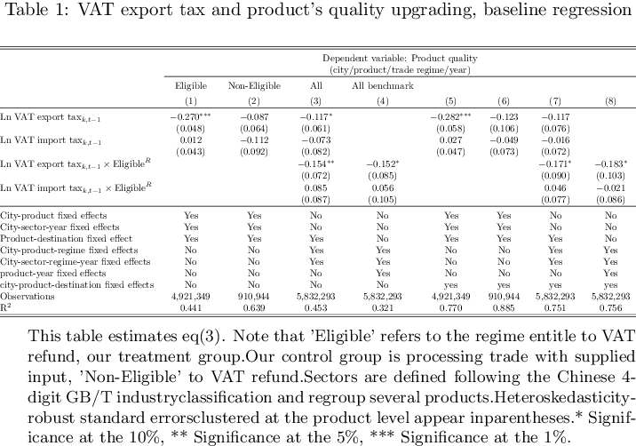

## Table 2: Baseline full fixed effect, with covariates city, regime destination, product

$$ \begin{aligned} \operatorname{Quality}_{c,k,j, t}^{R} &=\alpha \ln \operatorname{VAT} \operatorname{Export} \operatorname{tax}_{k, t-1} \times \text { Eligibility }^{R} \\ &+\lambda X_{c,k,j, t-1}^{R}+F E_{c,k}^{R}+F E_{c,s,t}^{R}+ F E_{k, t}+\epsilon_{ck,j, t}^{R} \end{aligned} $$

- Column 1: Estimate for eligible regime only
  - FE:
    - city-product: `fe_ck`
    - city-sector-year: `fe_cst`
    - product-destination: `fe_pj`
- Column 2: Estimate for non-eligible regime only
  - FE:
    - city-product: `fe_ck`
    - city-sector-year: `fe_cst`
    - product-destination: `fe_pj`
- Column 3: Full estimate without product-year FE -> Get two coefficients
  - FE:
    - city-product-regime: `fe_ckr`
    - city-sector-regime-year: `fe_csrt`
    - product-destination: `fe_pj`
- Column 4: Baseline estimate -> Focus on the coef of interest only
  - FE:
    - city-product-regime: `fe_ckr`
    - city-sector-regime-year: `fe_csrt`
    - product-year: `fe_kt`

Sector is defined as the GBT 4 digits

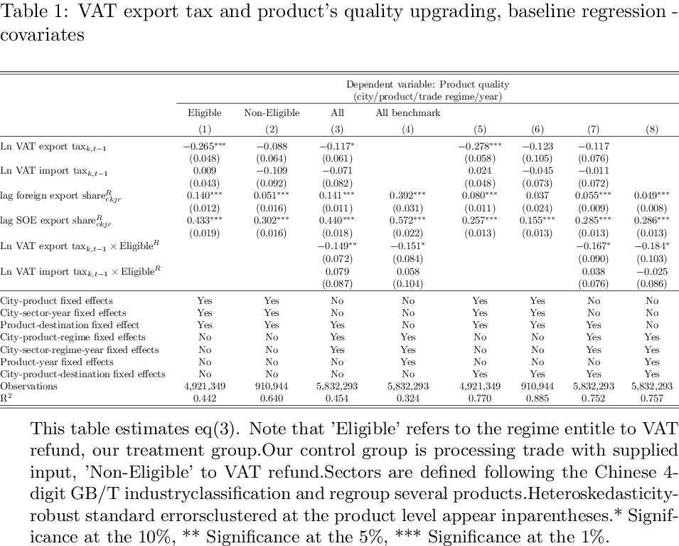

## Table 3: Baseline full fixed effect, with covariates city, regime, product

$$ \begin{aligned} \operatorname{Quality}_{c,k,j, t}^{R} &=\alpha \ln \operatorname{VAT} \operatorname{Export} \operatorname{tax}_{k, t-1} \times \text { Eligibility }^{R} \\ &+\lambda X_{c,k,j, t-1}^{R}+F E_{c,k}^{R}+F E_{c,s,t}^{R}+ F E_{k, t}+\epsilon_{ck,j, t}^{R} \end{aligned} $$

- Column 1: Estimate for eligible regime only
  - FE:
    - city-product: `fe_ck`
    - city-sector-year: `fe_cst`
    - product-destination: `fe_pj`
- Column 2: Estimate for non-eligible regime only
  - FE:
    - city-product: `fe_ck`
    - city-sector-year: `fe_cst`
    - product-destination: `fe_pj`
- Column 3: Full estimate without product-year FE -> Get two coefficients
  - FE:
    - city-product-regime: `fe_ckr`
    - city-sector-regime-year: `fe_csrt`
    - product-destination: `fe_pj`
- Column 4: Baseline estimate -> Focus on the coef of interest only
  - FE:
    - city-product-regime: `fe_ckr`
    - city-sector-regime-year: `fe_csrt`
    - product-year: `fe_kt`

Sector is defined as the GBT 4 digits

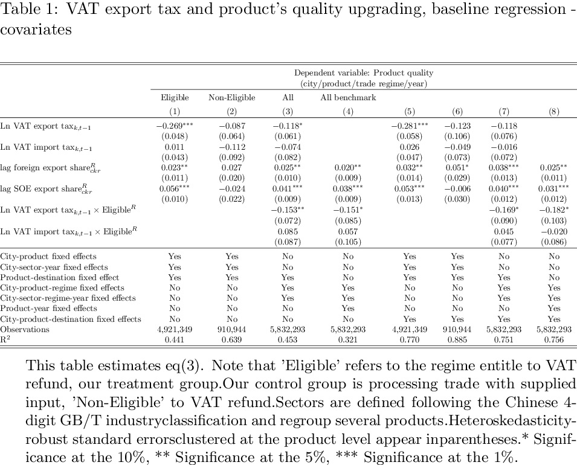

# Generate reports

```
Report Available at this adress:
 /Users/thomas/Google Drive/Projects/GitHub/Repositories/VAT_rebate_quality_china/02_data_analysis/00_analysis/00_analysis_table_1_POC/Reports/00_baseline_empirical_export_share_cov.html
```